[figure not shown]

[OHI Science](http://ohi-science.org) | [Citation policy](https://github.com/OHI-Science/ohiprep/releases)

# OHI: Sea Level Rise Pressure Layer 2015

Compiled on Mon Nov 9 17:21:50 2015 by afflerbach

# 1 Summary

This script creates the **sea level rise** pressure layer used for OHI 2015 global assessment.

**Overview:**

- All negative values, indicating decreases in sea level, were set to zero
- Data was resampled from the native cell resolution (0.25 degrees) to ~ 1km
- The reference point was set as the 99.99th quantile of the data distribution to rescale all values from 0 to 1
- All NA cells were filled in through nearest neighbor interpolation

# 2 Updates from previous assessment

# 3 Data Source

**Reference**: The altimeter products were produced and distributed by Aviso (http://www.aviso.altimetry.fr/), as part of the Ssalto ground processing segment. [AVISO](http://www.aviso.altimetry.fr/en/data/products/ocean-indicators-products/mean-sea-level/products-images.html)

**Downloaded**: January 12, 2015

**Description**: Annual rate of sea level rise in mm

**Native data resolution**: 0.25 degree grid cells

**Time range**: January 1993 - June 2014

**Format**: NetCDF

## 3.1 Steps

1. Create raster of original data (came as .nc)
2. Reproject to mollweide
3. Calculate cumulative sea level rise over all years
4. Clip all negative values (values that indicate decreasing sea level)
5. resample to 1km
6. rescale using 99.99 percentile
7. Interpolate and replace NA cells with interpolated values (use Python - arcpy for this)
8. Clip out ocean using ocean raster at 1km cell size
9. Create raster of just the interpolated cells

### 3.1.1 Setup

```r
    dir_N = c('Windows' = '//neptune.nceas.ucsb.edu/data_edit',
              'Darwin'  = '/Volumes/data_edit',
              'Linux'   = '/var/data/ohi')[[ Sys.info()[['sysname']] ]]


knitr::opts_knit$set(root.dir = file.path(dir_N,'git-annex/globalprep/Pressures_SeaLevelRise'))

#libraries

library(raster)
library(rgdal)
library(rasterVis)
library(RColorBrewer)
library(maptools)


# set tmp directory

tmpdir='~/big/R_raster_tmp'
dir.create(tmpdir, showWarnings=F)
rasterOptions(tmpdir=tmpdir)

#set colors for plotting

cols = rev(colorRampPalette(brewer.pal(11, 'Spectral'))(255)) # rainbow color scheme
```

### 3.1.2 1. Create raster from original NetCDF file

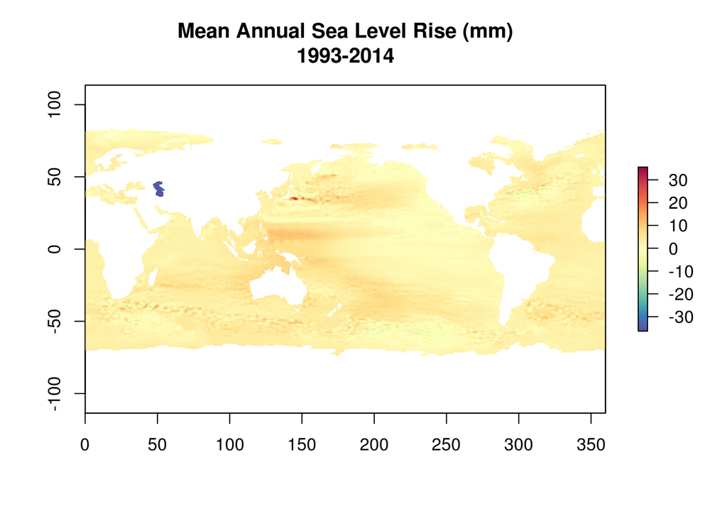

```r
# The following 3 lines were done once to create raster from downloaded NetCDF.
# No longer need to run these

    #library(ncdf4)

    #r <- raster('raw/MSL_Map_MERGED_Global_IB_RWT_NoGIA_Adjust.nc')
    #writeRaster(r,'tmp/MSL_Map_MERGED_Global_IB_RWT_NoGIA_Adjust.tif')


# Read in raw data

    r <- raster('tmp/MSL_Map_MERGED_Global_IB_RWT_NoGIA_Adjust.tif')

    plot(r,col=cols,main='Mean Annual Sea Level Rise (mm)\n1993-2014')
```

### 3.1.3 2. Reproject raster to mollweide and rotate to extent -180 to 180 degrees

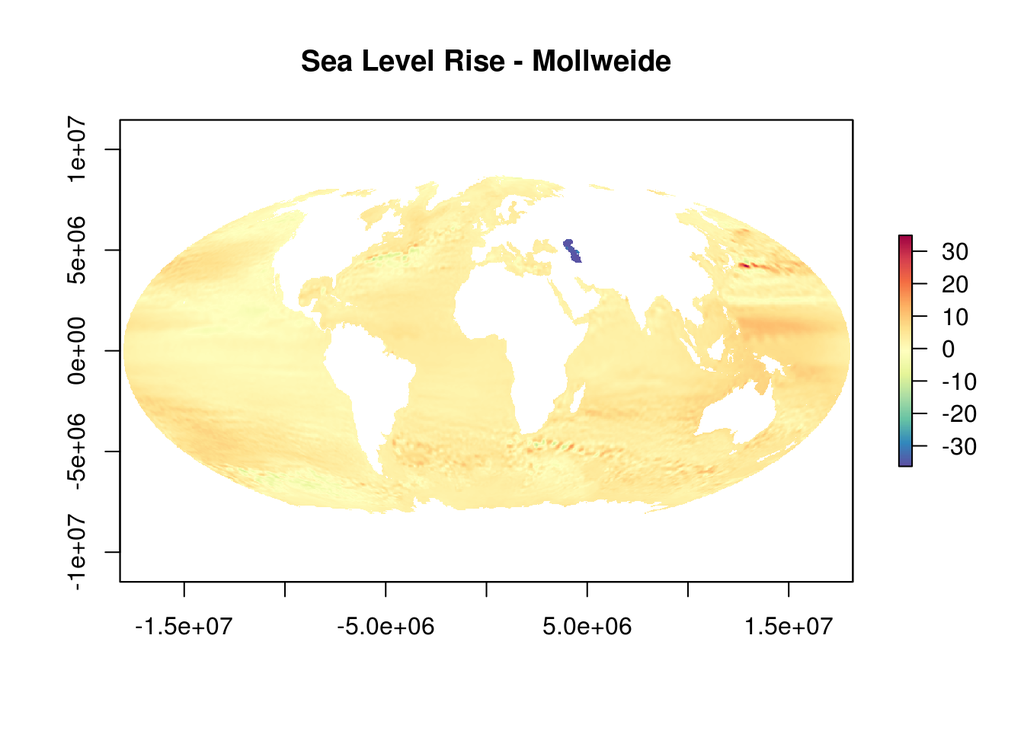

```r
  r = rotate(r) #rotate raster: -180 to 180

  #define initial projection. Helps avoid errors when reprojecting to mollweide
  projection(r) <- "+proj=longlat +datum=WGS84 +ellps=WGS84 +towgs84=0,0,0"

  mollCRS <- CRS('+proj=moll')

  slr_moll <- projectRaster(r, crs=mollCRS, over=T)

  plot(slr_moll,main='Sea Level Rise - Mollweide',col=cols)
```

### 3.1.4 3. Multiply mean annual sea level rise by number of years in dataset to get a total change in mm between 1993-2014

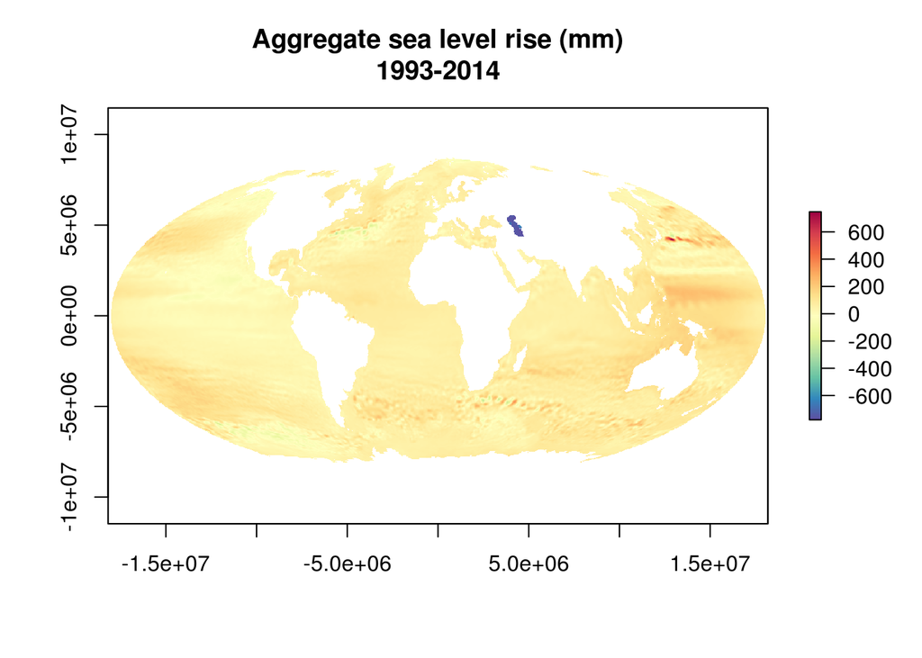

```r
# (3) Multiply annual rate by all years in dataset

    # data used to create r comes from January 1993 - June 2014 (21.5 years)
    # Multiply values by 21+5/12 = 21.41667

      slr_moll <- slr_moll*21.41667

      plot(slr_moll,col=cols,main='Aggregate sea level rise (mm)\n1993-2014')
```

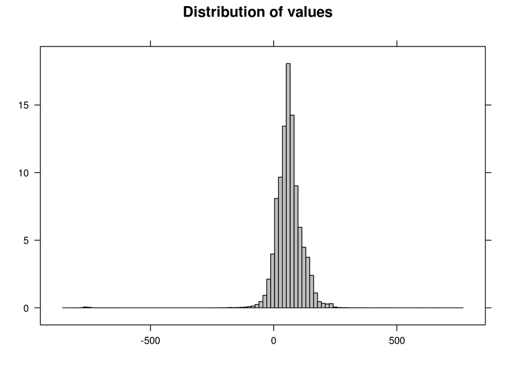

```r
      histogram(slr_moll,main ='Distribution of values')
```

### 3.1.5 4. All values below zero indicate a decrease in sea level rise.

We choose to disregard these as the impact of sea level rise is focused only on the increase in sea level

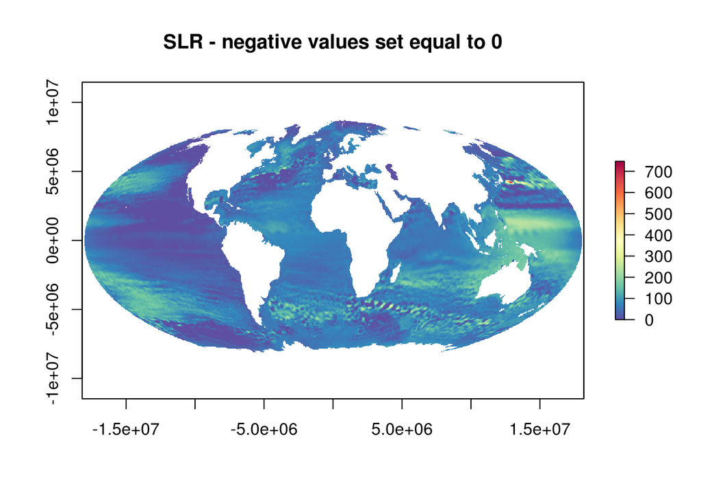

```r
# (4) Clip all negative values to 0

      slr_moll[slr_moll<0]<-0

      plot(slr_moll,main='SLR - negative values set equal to 0',col=cols)
```

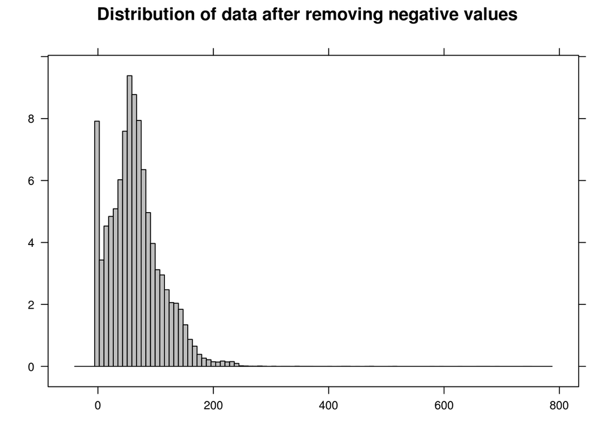

```r
      histogram(slr_moll,main ='Distribution of data after removing negative values')
```

### 3.1.6 5. Resample layer to 1km resolution

Original resolution of the data is 0.25 degrees. To resample the data to 1km resolution, a template ocean raster that is at the desired resolution (~1km) and contains all cells included within OHI regions, is used.

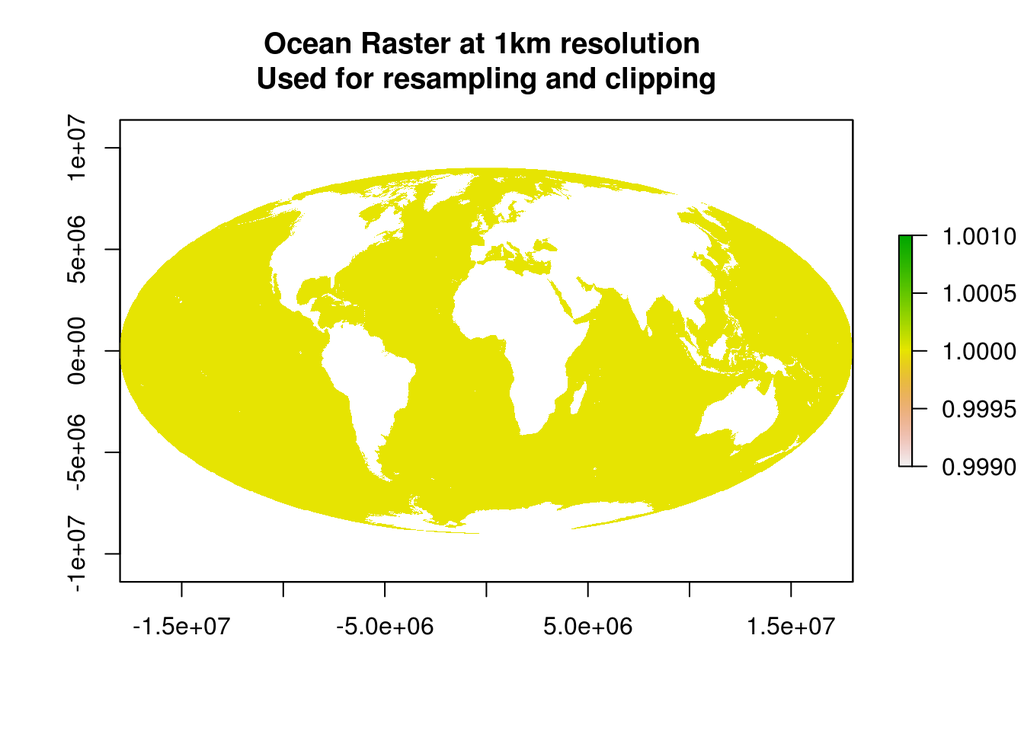

```r
    #ocean is a raster with all land clipped out - at 1km with value of 1
    ocean = raster(file.path(dir_N,'model/GL-NCEAS-Halpern2008/tmp/ocean.tif'))
    plot(ocean,main='Ocean Raster at 1km resolution \nUsed for resampling and clipping')
```

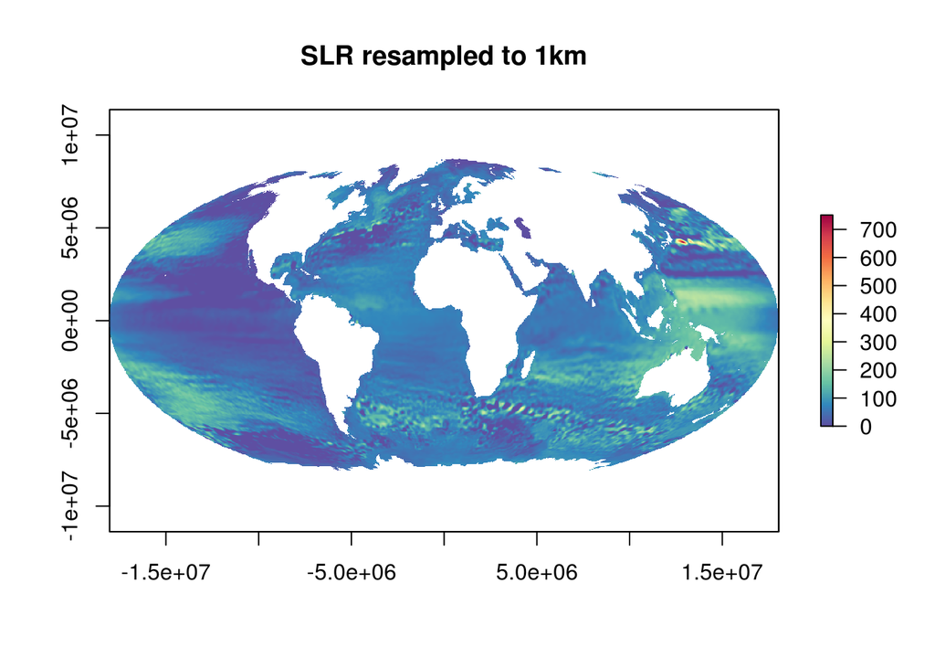

```r
    slr_1km = resample(slr_moll,ocean,method='ngb')

    plot(slr_1km,main='SLR resampled to 1km' ,col=cols)
```

### 3.1.7 6. Rescale using the reference point (99.99 quantile)

All values at or above the 99.99th quantile (512.8) are set to equal 1.

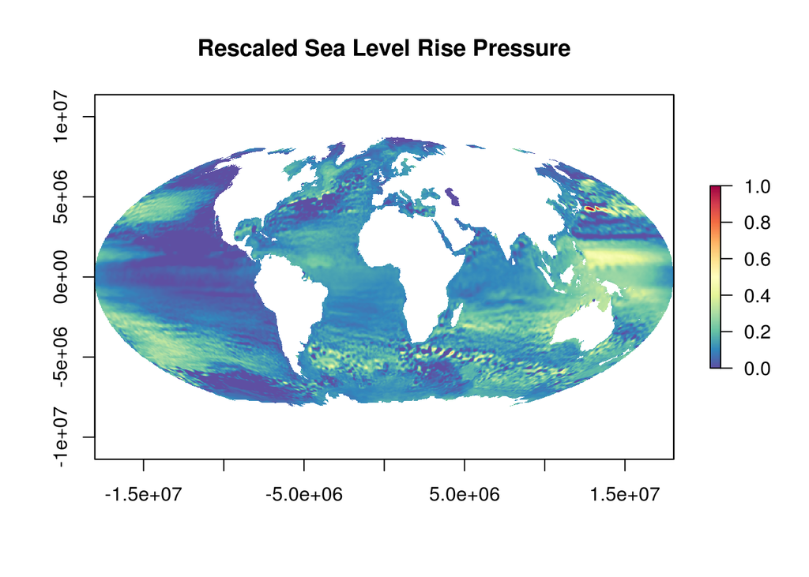

```r
    #get reference point

    ref = quantile(slr_1km,prob=0.9999)

    #normalize by the reference point - cap all values greater than 1 to 1
    r_resc <- calc(slr_1km,fun=function(x){ifelse(x>ref,1,x/ref)})

    plot(r_resc,main='Rescaled Sea Level Rise Pressure',col=cols)
```

### 3.1.8 7. Interpolation

Interpolating the data was done using ArcGIS. All NA cells were interpolated using nearest neighbor. The python script can be found [here](https://github.com/OHI-Science/ohiprep/blob/master/globalprep/Pressures_SeaLevelRise/scripts/SLR_interpolation.py)

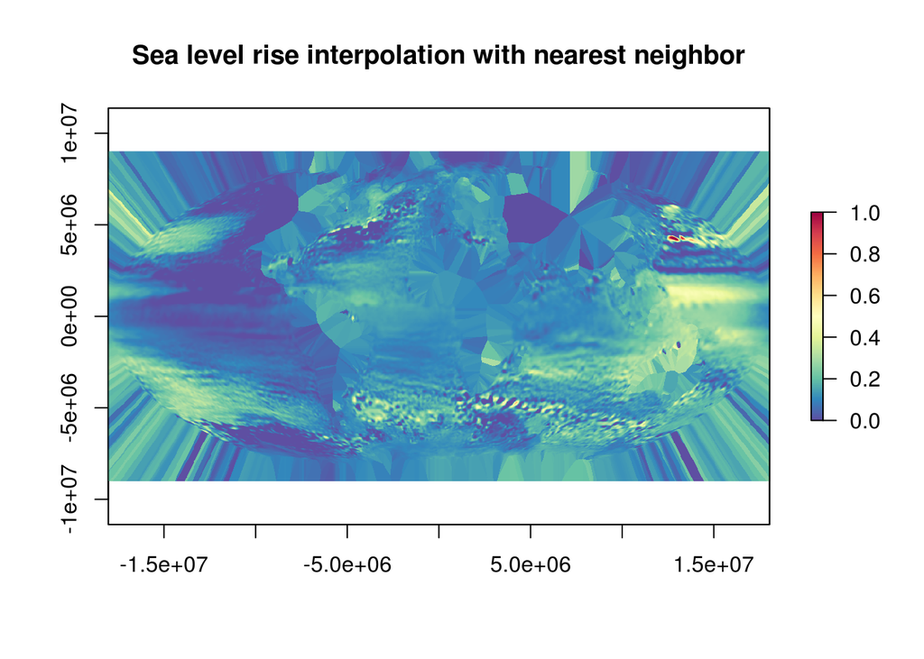

```r
  r_int = raster('tmp/slr_moll_nonlog_1km_resc_int.tif')
  plot(r_int,main='Sea level rise interpolation with nearest neighbor',col=cols)
```

### 3.1.9 8. Clip out ocean & Finalize layer

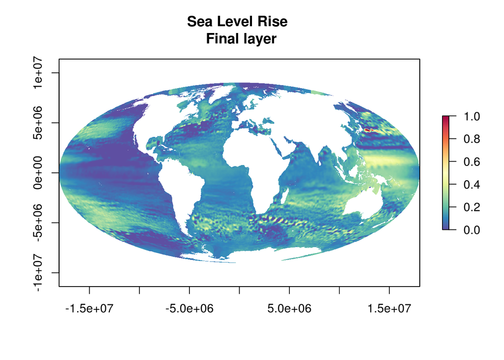

```r
  r_final = mask(r_int,ocean)

  plot(r_final,main='Sea Level Rise \n Final layer',col=cols)
```

### 3.1.10 9. Create interpolated cells raster

The cells that were filled in using the nearest neighbor interpolation are identified in a single raster.

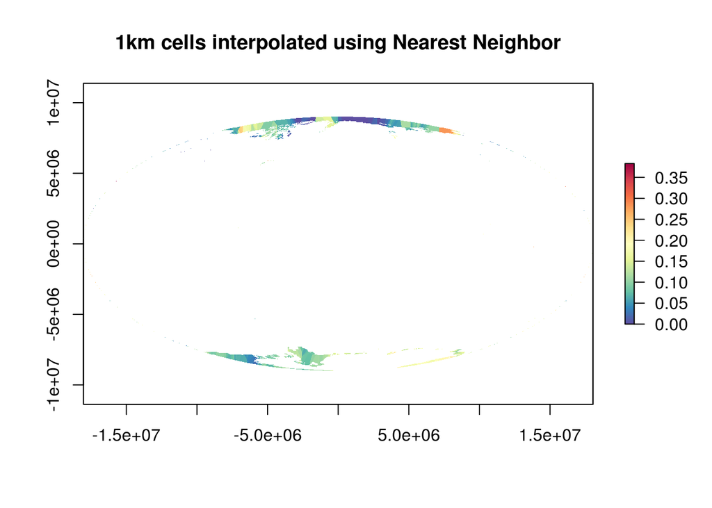

```r
interp = mask(r_final,slr_1km,inverse=TRUE)

plot(interp,col=cols,main='1km cells interpolated using Nearest Neighbor')
```